# Introduction to Data Set

We'll be working with a dataset on the job outcomes of students who graduated from college between 2010 and 2012. The original data on job outcomes was released by [American Community Survey](https://www.census.gov/programs-surveys/acs/), which conducts surveys and aggregates the data. FiveThirtyEight cleaned the dataset and released it on their [Github repo](https://github.com/fivethirtyeight/data/tree/master/college-majors).

```python
import pandas as pd
import matplotlib.pyplot as plt
%matplotlib inline

recent_grads = pd.read_csv("recent-grads.csv")
print(recent_grads.iloc[0])
print(recent_grads.head())
print(recent_grads.tail())
print(recent_grads.describe())
recent_grads = recent_grads.dropna()
```

```
Rank                                        1
Major_code                               2419
Major                   PETROLEUM ENGINEERING
Total                                    2339
Men                                      2057
Women                                     282
Major_category                    Engineering
ShareWomen                           0.120564
Sample_size                                36
Employed                                 1976
Full_time                                1849
Part_time                                 270
Full_time_year_round                     1207
Unemployed                                 37
Unemployment_rate                   0.0183805
Median                                 110000
P25th                                   95000
P75th                                  125000
College_jobs                             1534
Non_college_jobs                          364
Low_wage_jobs                             193
Name: 0, dtype: object
   Rank  Major_code                                      Major    Total  \
0     1        2419                      PETROLEUM ENGINEERING   2339.0
1     2        2416             MINING AND MINERAL ENGINEERING    756.0
2     3        2415                  METALLURGICAL ENGINEERING    856.0
3     4        2417  NAVAL ARCHITECTURE AND MARINE ENGINEERING   1258.0
4     5        2405                       CHEMICAL ENGINEERING  32260.0

       Men    Women Major_category  ShareWomen  Sample_size  Employed  \
0   2057.0    282.0    Engineering    0.120564           36      1976
1    679.0     77.0    Engineering    0.101852            7       640
2    725.0    131.0    Engineering    0.153037            3       648
3   1123.0    135.0    Engineering    0.107313           16       758
4  21239.0  11021.0    Engineering    0.341631          289     25694

       ...        Part_time  Full_time_year_round  Unemployed  \
0      ...              270                  1207          37
1      ...              170                   388          85
2      ...              133                   340          16
```

[output cut: 88 more lines]

```
min    18500.000000   22000.000000       0.000000          0.000000
25%    24000.000000   42000.000000    1675.000000       1591.000000
50%    27000.000000   47000.000000    4390.000000       4595.000000
75%    33000.000000   60000.000000   14444.000000      11783.000000
max    95000.000000  125000.000000  151643.000000     148395.000000

       Low_wage_jobs
count     173.000000
mean     3859.017341
std      6944.998579
min         0.000000
25%       340.000000
50%      1231.000000
75%      3466.000000
max     48207.000000
```

# Scatter Plots

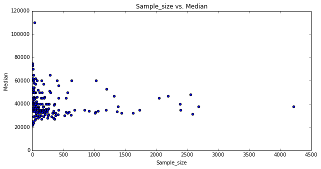

```python
ax = recent_grads.plot(x = "Sample_size",
                       y = "Median",
                       kind = "scatter",
                       figsize = (10,5),
                       xlim = (0,4500),
                       title = "Sample_size vs. Median")
```

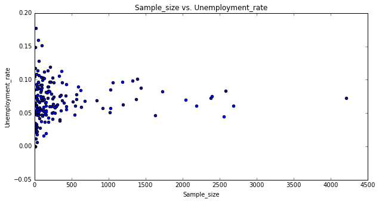

```python
ax = recent_grads.plot(x = "Sample_size",
                       y = "Unemployment_rate",
                       kind = "scatter",
                       figsize = (10,5),
                       xlim = (0,4500),
                       title = "Sample_size vs. Unemployment_rate")
```

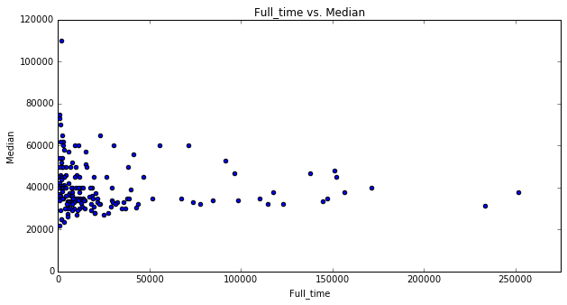

```python
ax = recent_grads.plot(x = "Full_time",
                       y = "Median",
                       kind = "scatter",
                       figsize = (10,5),
                       xlim = (0,275000),
                       title = "Full_time vs. Median")
```

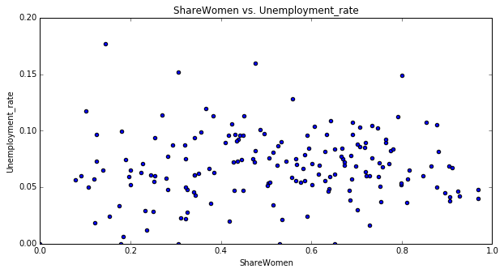

```python
ax = recent_grads.plot(x = "ShareWomen",
                       y = "Unemployment_rate",
                       kind = "scatter",
                       figsize = (10,5),
                       xlim = (0,1), ylim = (0,0.2),
                       title = "ShareWomen vs. Unemployment_rate")
```

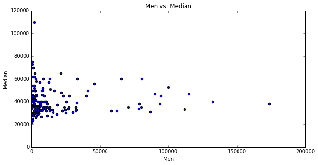

```python
ax = recent_grads.plot(x = "Men",
                       y = "Median",
                       kind = "scatter",
                       figsize = (10,5),
                       xlim = (0,200000),
                       title = "Men vs. Median")
```

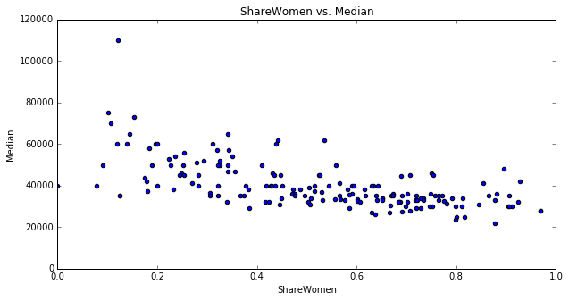

```python
ax = recent_grads.plot(x = "ShareWomen",
                       y = "Median",
                       kind = "scatter",
                       figsize = (10,5),
                       xlim = (0,1),
                       title = "ShareWomen vs. Median")
```

# Findings

- Students in more popular majors do not make more money.
- Students majored in subjects that were majority female make less money.
- There is no link between the number of full-time employees and median salary

# Histograms

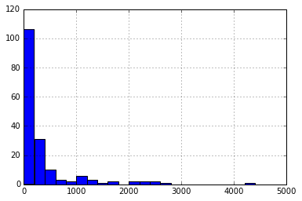

```python
ax = recent_grads["Sample_size"].hist(bins = 25, range = (0, 5000))
```

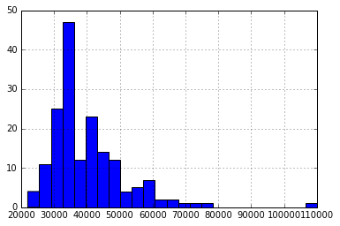

```python
ax = recent_grads["Median"].hist(bins = 25)
```

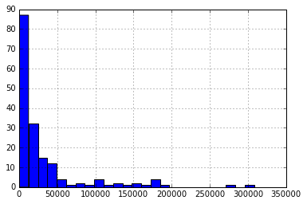

```python
ax = recent_grads["Employed"].hist(bins = 25)
```

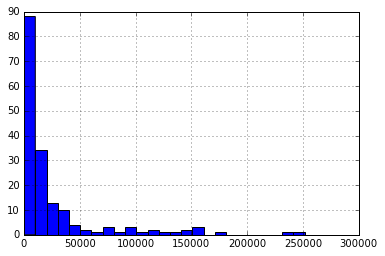

```python
ax = recent_grads["Full_time"].hist(bins = 25)
```

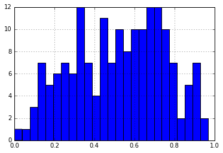

```python
ax = recent_grads["ShareWomen"].hist(bins = 25)
```

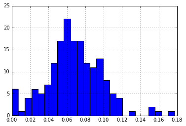

```python
ax = recent_grads["Unemployment_rate"].hist(bins = 25)
```

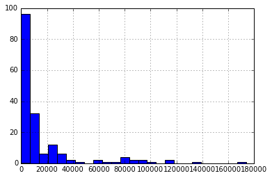

```python
ax = recent_grads["Men"].hist(bins = 25)
```

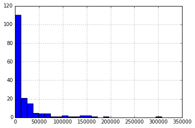

```python
ax = recent_grads["Women"].hist(bins = 25)
```

# Findings

- More majors are predominantly female
- The most common median salary range is (30000 - 35000)